# This is Assignment 12 - Thienkim Le

## Requirement 3

Using the Planets dataset from Seaborn, determine the number of rows and columns in the dataset.

```python
import seaborn as sns

# Load the Planets dataset
planets = sns.load_dataset('planets')

# Check the shape of the dataset
num_rows, num_columns = planets.shape

print("Number of rows:", num_rows)
print("Number of columns:", num_columns)
```

```
Number of rows: 1035
Number of columns: 6
```

## Requirement 4

Using the head() method, show the top fifty rows in the Planets dataset.

```python
import seaborn as sns

# Load the Planets dataset
planets = sns.load_dataset('planets')

# Display the top fifty rows
print(planets.head(50))
```

```
                       method  number  orbital_period     mass  distance  year
0             Radial Velocity       1      269.300000   7.1000     77.40  2006
1             Radial Velocity       1      874.774000   2.2100     56.95  2008
2             Radial Velocity       1      763.000000   2.6000     19.84  2011
3             Radial Velocity       1      326.030000  19.4000    110.62  2007
4             Radial Velocity       1      516.220000  10.5000    119.47  2009
5             Radial Velocity       1      185.840000   4.8000     76.39  2008
6             Radial Velocity       1     1773.400000   4.6400     18.15  2002
7             Radial Velocity       1      798.500000      NaN     21.41  1996
8             Radial Velocity       1      993.300000  10.3000     73.10  2008
9             Radial Velocity       2      452.800000   1.9900     74.79  2010
10            Radial Velocity       2      883.000000   0.8600     74.79  2010
11            Radial Velocity       1      335.100000   9.8800     39.43  2009
12            Radial Velocity       1      479.100000   3.8800     97.28  2008
13            Radial Velocity       3     1078.000000   2.5300     14.08  1996
```

[output cut: 36 more lines]

## Requirement 5

Use the following seeds for RandomState() to demonstrate that the function returns the same random numbers for constant seeds:

- RandomState(42)
- RandomState(99)
- RandomState(42)
- RandomState(99)

```python
import numpy as np

# Create RandomState objects with constant seeds
rng1 = np.random.RandomState(42)
rng2 = np.random.RandomState(99)
rng3 = np.random.RandomState(42)
rng4 = np.random.RandomState(99)

# Print random numbers using each RandomState object
print(rng1.rand(5), '\n')
print(rng2.rand(5), '\n')
print(rng3.rand(5), '\n')
print(rng4.rand(5), '\n')
```

```
[0.37454012 0.95071431 0.73199394 0.59865848 0.15601864]

[0.67227856 0.4880784  0.82549517 0.03144639 0.80804996]

[0.37454012 0.95071431 0.73199394 0.59865848 0.15601864]

[0.67227856 0.4880784  0.82549517 0.03144639 0.80804996]
```

## Requirement 6

Use rand(5) to produce the following dataframe. Naturally, values will vary.

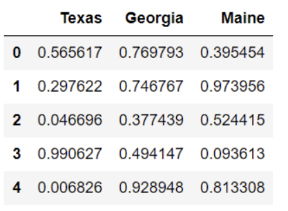

```python
import numpy as np
import pandas as pd

# Generate random numbers between 0 and 1
data = np.random.rand(5, 3)

# Create a DataFrame from the NumPy array
df = pd.DataFrame(data, columns=['Texas', 'Georgia', 'Maine'])

print(df)
```

```
      Texas   Georgia     Maine
0  0.354235  0.304410  0.371687
1  0.435530  0.829016  0.805984
2  0.787829  0.727904  0.485131
3  0.872894  0.736434  0.471826
4  0.782614  0.417258  0.707763
```

## Requirement 7

Output the common aggregates for the Planets dataset dropping rows with missing values.

```python
import seaborn as sns

# Load the Planets dataset
planets = sns.load_dataset('planets')

# Drop rows with missing values
planets_cleaned = planets.dropna()

# Output common aggregates
print(planets_cleaned.describe())
```

```
          number  orbital_period        mass    distance         year
count  498.00000      498.000000  498.000000  498.000000   498.000000
mean     1.73494      835.778671    2.509320   52.068213  2007.377510
std      1.17572     1469.128259    3.636274   46.596041     4.167284
min      1.00000        1.328300    0.003600    1.350000  1989.000000
25%      1.00000       38.272250    0.212500   24.497500  2005.000000
50%      1.00000      357.000000    1.245000   39.940000  2009.000000
75%      2.00000      999.600000    2.867500   59.332500  2011.000000
max      6.00000    17337.500000   25.000000  354.000000  2014.000000
```

## Requirement 8

Output a list of the datasets that install with Seaborn.

```python
import seaborn as sns

# Get a list of datasets that come with Seaborn
datasets = sns.get_dataset_names()

# Output the list of datasets
print("Datasets that come with Seaborn:")
for dataset in datasets:
    print("-", dataset)
```

```
Datasets that come with Seaborn:
- anagrams
- anscombe
- attention
- brain_networks
- car_crashes
- diamonds
- dots
- dowjones
- exercise
- flights
- fmri
- geyser
- glue
- healthexp
- iris
- mpg
- penguins
- planets
- seaice
- taxis
- tips
- titanic
- anagrams
- anagrams
- anscombe
- anscombe
- attention
- attention
- brain_networks
- brain_networks
- car_crashes
- car_crashes
- diamonds
- diamonds
- dots
- dots
- dowjones
- dowjones
- exercise
```

[output cut: 34 more lines]

```
- dowjones
- exercise
- flights
- fmri
- geyser
- glue
- healthexp
- iris
- mpg
- penguins
- planets
- seaice
- taxis
- tips
- titanic
```

## Requirement 9

Output the top five rows of five Pandas datasets

```python
import seaborn as sns

# Load the datasets
iris = sns.load_dataset('iris')
tips = sns.load_dataset('tips')
titanic = sns.load_dataset('titanic')
mpg = sns.load_dataset('mpg')
flights = sns.load_dataset('flights')

# Output the top five rows of each dataset
print("Top five rows of iris dataset:")
print(iris.head())

print("\nTop five rows of tips dataset:")
print(tips.head())

print("\nTop five rows of titanic dataset:")
print(titanic.head())

print("\nTop five rows of mpg dataset:")
print(mpg.head())

print("\nTop five rows of flights dataset:")
print(flights.head())
```

```
Top five rows of iris dataset:
   sepal_length  sepal_width  petal_length  petal_width species
0           5.1          3.5           1.4          0.2  setosa
1           4.9          3.0           1.4          0.2  setosa
2           4.7          3.2           1.3          0.2  setosa
3           4.6          3.1           1.5          0.2  setosa
4           5.0          3.6           1.4          0.2  setosa

Top five rows of tips dataset:
   total_bill   tip     sex smoker  day    time  size
0       16.99  1.01  Female     No  Sun  Dinner     2
1       10.34  1.66    Male     No  Sun  Dinner     3
2       21.01  3.50    Male     No  Sun  Dinner     3
3       23.68  3.31    Male     No  Sun  Dinner     2
4       24.59  3.61  Female     No  Sun  Dinner     4

Top five rows of titanic dataset:
   survived  pclass     sex   age  sibsp  parch     fare embarked  class  \
0         0       3    male  22.0      1      0   7.2500        S  Third
1         1       1  female  38.0      1      0  71.2833        C  First
2         1       3  female  26.0      0      0   7.9250        S  Third
3         1       1  female  35.0      1      0  53.1000        S  First
4         0       3    male  35.0      0      0   8.0500        S  Third

     who  adult_male deck  embark_town alive  alone
0    man        True  NaN  Southampton    no  False
1  woman       False    C    Cherbourg   yes  False
2  woman       False  NaN  Southampton   yes   True
3  woman       False    C  Southampton   yes  False
4    man        True  NaN  Southampton    no   True

Top five rows of mpg dataset:
    mpg  cylinders  displacement  horsepower  weight  acceleration  \
0  18.0          8         307.0       130.0    3504          12.0
1  15.0          8         350.0       165.0    3693          11.5
2  18.0          8         318.0       150.0    3436          11.0
3  16.0          8         304.0       150.0    3433          12.0
4  17.0          8         302.0       140.0    3449          10.5

   model_year origin                       name
0          70    usa  chevrolet chevelle malibu
1          70    usa          buick skylark 320
2          70    usa         plymouth satellite
3          70    usa              amc rebel sst
4          70    usa                ford torino

Top five rows of flights dataset:
   year month  passengers
0  1949   Jan         112
1  1949   Feb         118
2  1949   Mar         132
3  1949   Apr         129
4  1949   May         121
```

## Requirement 10

Apply the describe() method to a planets.groupby() object.

```python
import seaborn as sns

# Load the Planets dataset
planets = sns.load_dataset('planets')

# Group the data by 'method' column
grouped_planets = planets.groupby('method')

# Apply describe() method to the grouped object
grouped_describe = grouped_planets.describe()

# Output the result
print(grouped_describe)
```

```
                              number                                           \
                               count      mean       std  min  25%  50%   75%
method
Astrometry                       2.0  1.000000  0.000000  1.0  1.0  1.0  1.00
Eclipse Timing Variations        9.0  1.666667  0.500000  1.0  1.0  2.0  2.00
Imaging                         38.0  1.315789  0.933035  1.0  1.0  1.0  1.00
Microlensing                    23.0  1.173913  0.387553  1.0  1.0  1.0  1.00
Orbital Brightness Modulation    3.0  1.666667  0.577350  1.0  1.5  2.0  2.00
Pulsar Timing                    5.0  2.200000  1.095445  1.0  1.0  3.0  3.00
Pulsation Timing Variations      1.0  1.000000       NaN  1.0  1.0  1.0  1.00
Radial Velocity                553.0  1.721519  1.157141  1.0  1.0  1.0  2.00
Transit                        397.0  1.954660  1.399119  1.0  1.0  1.0  2.00
Transit Timing Variations        4.0  2.250000  0.500000  2.0  2.0  2.0  2.25

                                   orbital_period                 ...  \
                               max          count           mean  ...
method                                                            ...
Astrometry                     1.0            2.0     631.180000  ...
Eclipse Timing Variations      2.0            9.0    4751.644444  ...
Imaging                        4.0           12.0  118247.737500  ...
Microlensing                   2.0            7.0    3153.571429  ...
Orbital Brightness Modulation  2.0            3.0       0.709307  ...
Pulsar Timing                  3.0            5.0    7343.021201  ...
Pulsation Timing Variations    1.0            1.0    1170.000000  ...
Radial Velocity                6.0          553.0     823.354680  ...
Transit                        7.0          397.0      21.102073  ...
Transit Timing Variations      3.0            3.0      79.783500  ...

                                distance            year               \
                                     75%      max  count         mean
method
Astrometry                       19.3225    20.77    2.0  2011.500000
Eclipse Timing Variations       500.0000   500.00    9.0  2010.000000
Imaging                         132.6975   165.00   38.0  2009.131579
Microlensing                   4747.5000  7720.00   23.0  2009.782609
Orbital Brightness Modulation  1180.0000  1180.00    3.0  2011.666667
Pulsar Timing                  1200.0000  1200.00    5.0  1998.400000
Pulsation Timing Variations          NaN      NaN    1.0  2007.000000
Radial Velocity                  59.2175   354.00  553.0  2007.518987
Transit                         650.0000  8500.00  397.0  2011.236776
```

[output cut: 16 more lines]

```

                                  max
method
Astrometry                     2013.0
Eclipse Timing Variations      2012.0
Imaging                        2013.0
Microlensing                   2013.0
Orbital Brightness Modulation  2013.0
Pulsar Timing                  2011.0
Pulsation Timing Variations    2007.0
Radial Velocity                2014.0
Transit                        2014.0
Transit Timing Variations      2014.0

[10 rows x 40 columns]
```

## Requirement 11

Apply the describe() and unstack() methods to a planets.groupby() object

```python
import seaborn as sns

# Load the Planets dataset
planets = sns.load_dataset('planets')

# Group the data by 'method' column
grouped_planets = planets.groupby('method')

# Apply describe() method to the grouped object
grouped_describe = grouped_planets.describe()

# Unstack the result to make it more readable
unstacked_describe = grouped_describe.unstack()

# Output the result
print(unstacked_describe)
```

```
               method
number  count  Astrometry                          2.0
               Eclipse Timing Variations           9.0
               Imaging                            38.0
               Microlensing                       23.0
               Orbital Brightness Modulation       3.0
                                                 ...
year    max    Pulsar Timing                    2011.0
               Pulsation Timing Variations      2007.0
               Radial Velocity                  2014.0
               Transit                          2014.0
               Transit Timing Variations        2014.0
Length: 400, dtype: float64
```

## Requirement 12

Output the first ten rows from the Seaborn titanic dataset

```python
import seaborn as sns

# Load the Titanic dataset
titanic = sns.load_dataset('titanic')

# Output the first ten rows
print(titanic.head(10))
```

```
   survived  pclass     sex   age  sibsp  parch     fare embarked   class  \
0         0       3    male  22.0      1      0   7.2500        S   Third
1         1       1  female  38.0      1      0  71.2833        C   First
2         1       3  female  26.0      0      0   7.9250        S   Third
3         1       1  female  35.0      1      0  53.1000        S   First
4         0       3    male  35.0      0      0   8.0500        S   Third
5         0       3    male   NaN      0      0   8.4583        Q   Third
6         0       1    male  54.0      0      0  51.8625        S   First
7         0       3    male   2.0      3      1  21.0750        S   Third
8         1       3  female  27.0      0      2  11.1333        S   Third
9         1       2  female  14.0      1      0  30.0708        C  Second

     who  adult_male deck  embark_town alive  alone
0    man        True  NaN  Southampton    no  False
1  woman       False    C    Cherbourg   yes  False
2  woman       False  NaN  Southampton   yes   True
3  woman       False    C  Southampton   yes  False
4    man        True  NaN  Southampton    no   True
5    man        True  NaN   Queenstown    no   True
6    man        True    E  Southampton    no   True
7  child       False  NaN  Southampton    no  False
8  woman       False  NaN  Southampton   yes  False
9  child       False  NaN    Cherbourg   yes  False
```

## Requirement 13

Use the groupby() method with the titanic dataset to show mean survival rates by sex and class.

```python
import seaborn as sns

# Load the Titanic dataset
titanic = sns.load_dataset('titanic')

# Group the data by 'sex' and 'class' columns and calculate the mean survival rate
survival_rates = titanic.groupby(['sex', 'class'])['survived'].mean()

# Output the result
print(survival_rates)
```

```
sex     class
female  First     0.968085
        Second    0.921053
        Third     0.500000
male    First     0.368852
        Second    0.157407
        Third     0.135447
Name: survived, dtype: float64
```

## Requirement 14

Use the pivot_table() method with the titanic dataset to show mean survival rates by sex and class.

```python
import seaborn as sns

# Load the Titanic dataset
titanic = sns.load_dataset('titanic')

# Use pivot_table to calculate mean survival rates by sex and class
survival_pivot = titanic.pivot_table(index='sex', columns='class', values='survived', aggfunc='mean')

# Output the result
print(survival_pivot)
```

```
class      First    Second     Third
sex
female  0.968085  0.921053  0.500000
male    0.368852  0.157407  0.135447
```

## Requirement 15

Use a multi-level pivot table to include age with the previous requirement.

```python
import seaborn as sns

# Load the Titanic dataset
titanic = sns.load_dataset('titanic')

# Use pivot_table to calculate mean survival rates by sex, class, and age
survival_pivot = titanic.pivot_table(index=['sex', 'class'], columns='age', values='survived', aggfunc='mean')

# Output the result
print(survival_pivot)
```

```
age            0.42   0.67   0.75   0.83   0.92      1.00   2.00   3.00   \
sex    class
female First     NaN    NaN    NaN    NaN    NaN       NaN   0.00    NaN
       Second    NaN    NaN    NaN    NaN    NaN       NaN   1.00    1.0
       Third     NaN    NaN    1.0    NaN    NaN  1.000000   0.25    0.0
male   First     NaN    NaN    NaN    NaN    1.0       NaN    NaN    NaN
       Second    NaN    1.0    NaN    1.0    NaN  1.000000   1.00    1.0
       Third     1.0    NaN    NaN    NaN    NaN  0.333333   0.00    1.0

age            4.00   5.00   ...  62.00  63.00  64.00  65.00  66.00  70.00  \
sex    class                 ...
female First     NaN    NaN  ...    1.0    1.0    NaN    NaN    NaN    NaN
       Second   1.00    1.0  ...    NaN    NaN    NaN    NaN    NaN    NaN
       Third    1.00    1.0  ...    NaN    1.0    NaN    NaN    NaN    NaN
male   First    1.00    NaN  ...    0.0    NaN    0.0    0.0    NaN    0.0
       Second    NaN    NaN  ...    1.0    NaN    NaN    NaN    0.0    0.0
       Third    0.25    NaN  ...    NaN    NaN    NaN    0.0    NaN    NaN

age            70.50  71.00  74.00  80.00
sex    class
female First     NaN    NaN    NaN    NaN
       Second    NaN    NaN    NaN    NaN
       Third     NaN    NaN    NaN    NaN
male   First     NaN    0.0    NaN    1.0
       Second    NaN    NaN    NaN    NaN
       Third     0.0    NaN    0.0    NaN

[6 rows x 88 columns]
```

## Requirement 16

Use the pivot_table() method to show row data by sex and column data by class when using aggfunc argument to aggregate survived by using sum and fare by mean.

```python
import seaborn as sns

# Load the Titanic dataset
titanic = sns.load_dataset('titanic')

# Use pivot_table to aggregate 'survived' by sum and 'fare' by mean,
# with row data by 'sex' and column data by 'class'
pivot_result = titanic.pivot_table(index='sex', columns='class', values=['survived', 'fare'], aggfunc={'survived': 'sum', 'fare': 'mean'})

# Output the result
print(pivot_result)
```

```
              fare                       survived
class        First     Second      Third    First Second Third
sex
female  106.125798  21.970121  16.118810       91     70    72
male     67.226127  19.741782  12.661633       45     17    47
```

## Requirement 17

Use matplotlib, pivot_table(), and the Seaborn births dataset to produce a plot of total births per year.

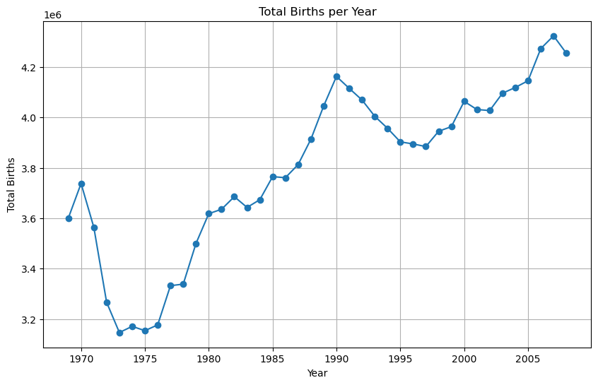

```python
import pandas as pd
import matplotlib.pyplot as plt

# Load the births dataset
births = pd.read_csv("https://raw.githubusercontent.com/jakevdp/data-CDCbirths/master/births.csv")

# Convert 'year' column to datetime
births['year'] = pd.to_datetime(births['year'], format='%Y')

# Create a pivot table to calculate total births per year
births_pivot = births.pivot_table(index=births['year'].dt.year, values='births', aggfunc='sum')

# Plot total births per year
plt.figure(figsize=(10, 6))
plt.plot(births_pivot.index, births_pivot['births'], marker='o', linestyle='-')
plt.title('Total Births per Year')
plt.xlabel('Year')
plt.ylabel('Total Births')
plt.grid(True)
plt.show()
```

## Requirement 18

Create an np array x based on range(11). Output the cubed contents of x.

```python
import numpy as np

# Create an array x based on range(11)
x = np.array(range(11))

# Calculate the cube of each element in x
cubed_x = x ** 3

# Output the cubed contents of x
print(cubed_x)
```

```
[   0    1    8   27   64  125  216  343  512  729 1000]
```

## Requirement 19

Use list comprehension with a list of string to convert all entries to uppercase. What happens when the list contains the value of None?

```python
# Example list containing strings and None
string_list = ['hello', 'world', None, 'python', None]

# Convert all entries to uppercase, handling None values
uppercase_list = [s.upper() if s is not None else None for s in string_list]

print(uppercase_list)
```

```
['HELLO', 'WORLD', None, 'PYTHON', None]
```

## Requirement 20

Convert the list from the previous requirement into a Pandas series. Demonstrate conversion to uppercase with the Pandas series.

```python
import pandas as pd

# Example list containing strings and None
string_list = ['hello', 'world', None, 'python', None]

# Convert the list to a Pandas Series
string_series = pd.Series(string_list)

# Convert all entries to uppercase in the Pandas Series, handling None values
uppercase_series = string_series.apply(lambda x: x.upper() if isinstance(x, str) else None)

print(uppercase_series)
```

```
0     HELLO
1     WORLD
2      None
3    PYTHON
4      None
dtype: object
```

## Requirement 21

Demonstrate the use of five Pandas str methods on a Pandas series named states created from a list of seven names of U.S. states

```python
import pandas as pd

# List of U.S. state names
state_names = ['California', 'New York', 'Texas', 'Florida', 'Washington', 'Illinois', 'Ohio']

# Create a Pandas Series
states = pd.Series(state_names)

# Demonstrate the use of Pandas str methods
# 1. str.lower(): Convert strings to lowercase
print("1. Lowercase:")
print(states.str.lower())
print()

# 2. str.upper(): Convert strings to uppercase
print("2. Uppercase:")
print(states.str.upper())
print()

# 3. str.len(): Compute the length of each string
print("3. Length of strings:")
print(states.str.len())
print()

# 4. str.contains(): Check if strings contain a substring
print("4. Contains 'o':")
print(states.str.contains('o'))
print()

# 5. str.replace(): Replace a substring with another substring
print("5. Replace 'i' with 'e':")
print(states.str.replace('i', 'e'))
```

```
1. Lowercase:
0    california
1      new york
2         texas
3       florida
4    washington
5      illinois
6          ohio
dtype: object

2. Uppercase:
0    CALIFORNIA
1      NEW YORK
2         TEXAS
3       FLORIDA
```

[output cut: 34 more lines]

## Requirement 22

Demonstrate the use of three regular expression examples using the states Pandas series

```python
import pandas as pd

# List of U.S. state names
state_names = ['California', 'New York', 'Texas', 'Florida', 'Washington', 'Illinois', 'Ohio']

# Create a Pandas Series
states = pd.Series(state_names)

# Regular expression examples:
# 1. Extract states starting with 'C'
print("1. States starting with 'C':")
print(states[states.str.contains('^C')])  # '^C' matches strings starting with 'C'
print()

# 2. Extract states containing 'o' followed by any character and ending with 'o'
print("2. States containing 'o' followed by any character and ending with 'o':")
print(states[states.str.contains('o.o$')])  # 'o.o$' matches strings containing 'o' followed by any character and ending with 'o'
print()

# 3. Replace 'o' with '0' in state names
print("3. Replace 'o' with '0' in state names:")
print(states.str.replace('o', '0'))  # Replace 'o' with '0' in each string
```

```
1. States starting with 'C':
0    California
dtype: object

2. States containing 'o' followed by any character and ending with 'o':
Series([], dtype: object)

3. Replace 'o' with '0' in state names:
0    Calif0rnia
1      New Y0rk
2         Texas
3       Fl0rida
4    Washingt0n
5      Illin0is
6          Ohi0
dtype: object
```

## Requirement 23

Demonstrate the use of three miscellaneous methods using the states Pandas series.

```python
import pandas as pd

# List of U.S. state names
state_names = ['California', 'New York', 'Texas', 'Florida', 'Washington', 'Illinois', 'Ohio']

# Create a Pandas Series
states = pd.Series(state_names)

# Miscellaneous methods examples:
# 1. str.startswith(): Check if strings start with a specified substring
print("1. States starting with 'C':")
print(states[states.str.startswith('C')])  # Extract states starting with 'C'
print()

# 2. str.split(): Split strings by a specified delimiter
print("2. Split states by space and get the first word:")
print(states.str.split().str[0])  # Split state names by space and get the first word
print()

# 3. str.isnumeric(): Check if strings contain only numeric characters
print("3. Check if state names contain only numeric characters:")
print(states.str.isnumeric())  # Check if state names contain only numeric characters
```

```
1. States starting with 'C':
0    California
dtype: object

2. Split states by space and get the first word:
0    California
1           New
2         Texas
3       Florida
4    Washington
5      Illinois
6          Ohio
dtype: object

3. Check if state names contain only numeric characters:
0    False
1    False
2    False
3    False
4    False
5    False
6    False
dtype: bool
```

## Requirement 24

Use markdown to describe the operations demonstrated in the section Example: Recipe Database in chapter 03.10

Example: Recipe Database This section illustrates how vectorized string operations in Pandas can effectively clean and process messy real-world data, using an open recipe database sourced from various web platforms. The goal is to parse the recipe data into ingredient lists, facilitating quick searches based on available ingredients.

1. Data Retrieval: The section begins by retrieving the recipe database, which is available in JSON format. The dataset comprises approximately 175,000 recipes spread across 17 columns. Each line of the file represents a JSON entry.
2. Data Inspection: A sample row from the dataset is examined to understand its structure. The row contains various fields such as recipe name, ingredients, URL, image, timestamps, and other metadata.
3. Exploratory Data Analysis (EDA):
- The length of ingredient lists is analyzed using str.len() method. Descriptive statistics reveal that the average ingredient list length is approximately 250 characters, ranging from 0 to nearly 10,000 characters.
- The recipe with the longest ingredient list is identified using np.argmax() function, showcasing the versatility of Pandas' string operations.
1. Data Exploration with Regular Expressions:
- Recipes categorized as breakfast foods are identified using regular expressions ('[Bb]reakfast'), yielding a count of 3524 breakfast recipes.
- The presence of cinnamon in recipes is determined using str.contains('[Cc]innamon'), resulting in 10526 recipes containing cinnamon.
- Possible misspellings of cinnamon as "cinamon" are also investigated using str.contains('[Cc]inamon'), revealing 11 occurrences.
1. Conclusion: The section concludes by highlighting the power of Pandas' string operations for data exploration and munging tasks. Python's strength in handling messy, real-world data is emphasized, showcasing how Pandas facilitates efficient data cleaning and analysis processes.

## Requirement 25

Create a NumPy date array using the date 01Jan2020 (use the date format of your choice). Use the arrange() method to create an array of seven dates starting with 01Jan2020 (use the date format of your choice).

```python
import numpy as np
import datetime

# Creating a NumPy date array with the date "01Jan2020"
start_date = np.array('2020-01-01', dtype=np.datetime64)

# Creating an array of seven dates starting with "01Jan2020"
seven_dates = np.arange(start_date, start_date + np.timedelta64(7, 'D'), dtype='datetime64[D]')

print(seven_dates)
```

```
['2020-01-01' '2020-01-02' '2020-01-03' '2020-01-04' '2020-01-05'
 '2020-01-06' '2020-01-07']
```

## Requirement 26

Construct a Pandas series object and use it to demonstrate indexing data by timestamps.

```python
import pandas as pd

# Create a Pandas Series with timestamps as indices
data = [10, 20, 30, 40, 50]
timestamps = ['2022-01-01', '2022-01-02', '2022-01-03', '2022-01-04', '2022-01-05']
timestamps = pd.to_datetime(timestamps)  # Convert to datetime objects
series = pd.Series(data, index=timestamps)

# Demonstrate indexing data by timestamps
print("Series with timestamps as indices:")
print(series)
print()

# Indexing data by timestamps
print("Indexing data by timestamps:")
print("Value at '2022-01-03':", series['2022-01-03'])
print("Values between '2022-01-02' and '2022-01-04':")
print(series['2022-01-02':'2022-01-04'])
```

```
Series with timestamps as indices:
2022-01-01    10
2022-01-02    20
2022-01-03    30
2022-01-04    40
2022-01-05    50
dtype: int64

Indexing data by timestamps:
Value at '2022-01-03': 30
Values between '2022-01-02' and '2022-01-04':
2022-01-02    20
2022-01-03    30
2022-01-04    40
dtype: int64
```

## Requirement 27

```python
# Install the pandas_datareader module
!pip install pandas-datareader

import pandas_datareader.data as web
import datetime

# Set the start and end dates for the data
start_date = datetime.datetime(2022, 1, 1)
end_date = datetime.datetime(2022, 12, 31)

# Ticker symbol of your choice (e.g., MSFT, AAPL, GOOGL)
ticker_symbol = 'MSFT'

# Use Pandas DataReader to get stock prices from Alpha Vantage
stock_data = web.DataReader(ticker_symbol, 'av-daily', start=start_date, end=end_date, api_key='YOUR_API_KEY')

# Display the stock data
print(stock_data)
```

[output not shown]

## Requirement 28

Use the timeit function to compare processes summing four Pandas dataframe objects using: • the typical approach (simple ‘+’ operations) • the pd.eval() approach

```python
import pandas as pd
import numpy as np
import timeit

# Create four Pandas DataFrame objects with random data
df1 = pd.DataFrame(np.random.randint(0, 100, size=(1000, 1000)))
df2 = pd.DataFrame(np.random.randint(0, 100, size=(1000, 1000)))
df3 = pd.DataFrame(np.random.randint(0, 100, size=(1000, 1000)))
df4 = pd.DataFrame(np.random.randint(0, 100, size=(1000, 1000)))

# Define the functions to compare
def typical_approach():
    result = df1 + df2 + df3 + df4

def eval_approach():
    result = pd.eval('df1 + df2 + df3 + df4')

# Measure the time taken for each approach
typical_time = timeit.timeit(typical_approach, number=10)
eval_time = timeit.timeit(eval_approach, globals=globals(), number=10)

# Print the results
print("Time taken for the typical approach:", typical_time)
print("Time taken for the pd.eval() approach:", eval_time)
```

```
Time taken for the typical approach: 0.061345199996139854
Time taken for the pd.eval() approach: 0.05198340001516044
```

## Requirement 29

Watch the following three Pandas videos: (include markdown with brief description of each video contents) https://pyvideo.org/search?q=pandas

[figure not shown]

Here are brief descriptions of the contents of the three Pandas videos, with markdown formatting:

1. What is pandas?

This video introduces the Python pandas library, which is a powerful data manipulation and analysis tool. It provides an overview of pandas data structures, including Series (one-dimensional labeled arrays) and DataFrames (two-dimensional labeled data structures with rows and columns). The video explains how pandas integrates well with other libraries like NumPy and Matplotlib, making it easier to work with structured data and perform data analysis tasks.

1. How do I manipulate strings?

This video focuses on string manipulation techniques in pandas. It covers various methods for handling text data, such as string slicing, concatenation, substring extraction, and pattern matching using regular expressions. The video demonstrates how to apply these string operations to Series and DataFrame columns containing text data, enabling efficient text cleaning, preprocessing, and feature engineering tasks.

1. More of your questions answered!

This video is likely a Q&A session or a collection of common questions and answers related to pandas. It might cover topics like data input/output operations, handling missing data, data visualization, advanced indexing and selection techniques, performance optimization, and integrating pandas with other libraries or tools. The goal is to address frequently asked questions and provide solutions to common challenges faced when working with pandas.

## Requirement 30

Use markdown to include a statement at the end of assignment-12.ipynb explaining your experiences with Assignment 12. Make this authentic (minimum of 2-3 sentences).

Working on Assignment 12 was an enriching experience. I found the tasks challenging yet rewarding, as they allowed me to apply and expand my knowledge of Pandas, NumPy, and other Python libraries. The exercises provided a great opportunity to practice data manipulation techniques and reinforced my understanding of data analysis concepts. Overall, it was a valuable learning journey that has further strengthened my skills in Python programming and data analysis.